### Models for Socio-Environmental Data

#### May 25, 2018

#### Table of Contents

I. Motivation

II. Problem

III. Premliminaries

IV. Pooled model

V. Intercepts for each site

VI. Intercepts vary with carbon level in site soils and slopes vary with fertilizer type

VII. Advanced problem 1: Slope and intercepts vary by site

VIII. Advanced problem 2: Model checking

#### I. Motivation

Multi-level models are a workhorse for understanding ecological processes because so many problems contain information at nested spatial scales, levels of organization, or categories. This problem will give you practice implementing the math that you wrote in the model building exercise on N<sub>2</sub>O emissions from agricultural soils. The deterministic models that we will use here are linear, but the approach applies equally well to non-linear forms. The data set that you will analyze is described in the companion document `MultilevelModelBuildingExercise.pdf`.

#### II. Problem

You will write JAGS code to implement models of increasing complexity and power.

#### III. Premliminaries

There are two sets of problems here, one focusing on model writing, the other focusing on writing code to implement the MCMC in JAGS. I suggest you work this way. Alternate between the model model writing and the model coding. Study the math, then use the math as a template for your code. If we had more time, I would have asked you to write the models.

You need to load some data and libraries. It is always a good idea to look at the data. Examine the head of the data frame for emissions. Note that the columns `group.index` and `fert.index` contain indices for sites and fertilizer types. You will need to understand how these are used in the “index trick” covered in lecture. Plot $N_2O$ emissions as a function of fertilizer input by group and fertilizer type.

```r
library(rjags)
```

```r
library(reshape)
library(ggplot2)
library(SESYNCBayes)
set.seed(5)
#y=N2OEmission
w=SiteCarbon
#names(y)
##In case someone has difficulty loading libraries
y=read.csv("/Users/Tom/Documents/EcologicalModelingCourse/_A_Master_Lab_Exercises/Multi-level models NO2/OldFiles/NO_2 emission all data for exercise.csv")
# y <- y[,2:9]
w=read.csv("/Users/Tom/Documents/EcologicalModelingCourse/_A_Master_Lab_Exercises/Multi-level models NO2/OldFiles/Site_level_carbon_data for exercise.csv")
# w <- w[,2:5]
w$mean=w$mean/100  #transform carbon % to proportion
y.n.sites = length(unique(y$group))
head(y)
```

```
##   X fertilizer group carbon n.input emission reps group.index fert.index
## 1 1          A    14    2.7     180    0.620   13          10          2
## 2 2          A    14    4.6     180    0.450   13          10          2
## 3 3          A    11    0.9     112    0.230   12           7          2
## 4 4          A    38    0.5     100    0.153   14          29          2
## 5 5          A     1    4.0     250    1.000    6           1          2
## 6 6          A    38    0.5     100    0.216   14          29          2
```

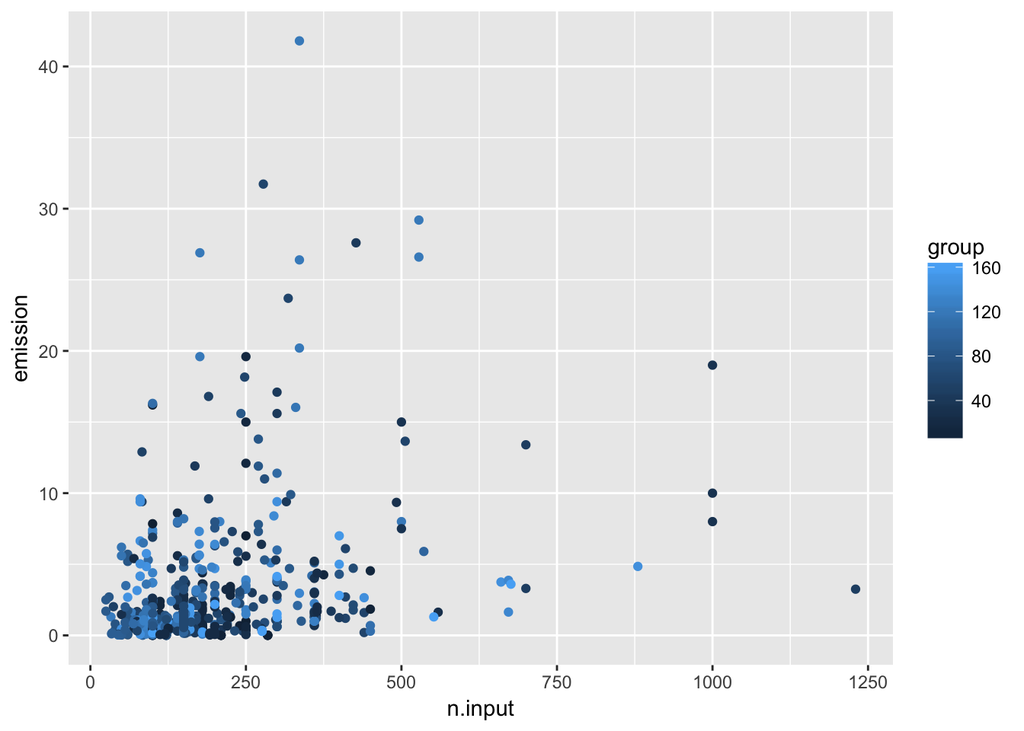

```r
qplot(n.input, emission, data=y, color =  group)
```

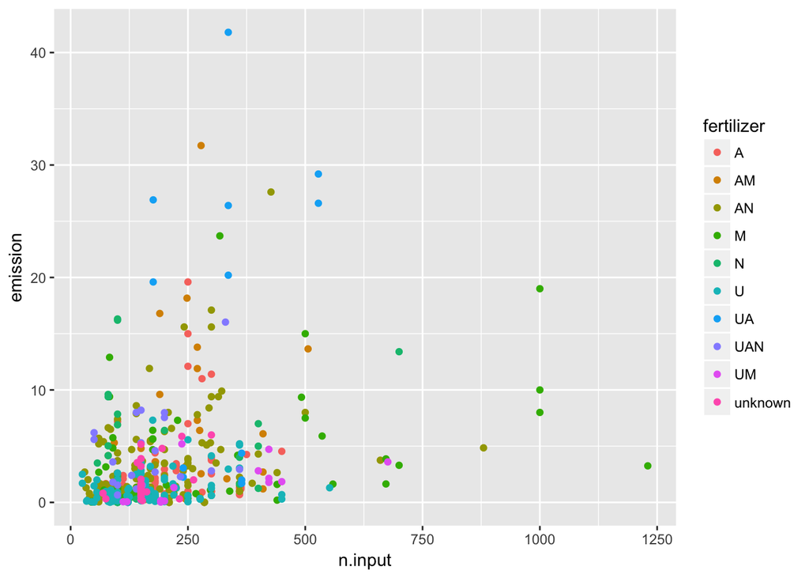

```r
qplot(n.input, emission, data=y, color =  fertilizer)
```

Later, you will also need a function to link the sequential indices used in JAGS to the groups (fertilizer and site) in the data. This kind of function is needed when sites or factors in data frames do not correspond to an uninterrupted sequence of integers needed for indices by JAGS. If there are letters or names or non-sequential numbers you will need a function like this to align the jags output with the factors, sites, etc. I provide this function below. It would be a good idea to understand what it does.

```r
group_from_index = function(group, group.index, output ){
  #group is a vector of group names or numbers (for factors or sites, etc.)
  #group.index is vector of sequential indices to group names or numbers.  It is a sequence of integers 1 to length(group)
  #output is a matrix or dataframe of JAGS output with number of rows = length(group). Each row contains statistics, etc from JAGS for each group.
  a = unique(as.vector(group))
  b = unique(group.index)
  group.key=as.data.frame(t(rbind(a,b))) #columns containing group indices paired with group name or number
  names(group.key)= c(names(as.data.frame(group)), names(as.data.frame(group.index)))
  link.column.name = names(group.key)[2] #name of column for merging output data with groups
  output2 = cbind(seq(1,nrow(output)),output) #give the output data sequential index the same as the group index
  colnames(output2)[1]=link.column.name
  group.data=as.data.frame(merge(group.key, output2, by = link.column.name )) #merge the JAGS output with the group names or numbers
  return(group.data)
}
```

#### IV. Pooled model

Your first task is to write a simple, “pooled” model where you gloss over differences in sites and fertilizer types and lump everything into a set of $x$ & $y$ pairs using the R template provided below. It is imperative that you study the data statement and match the variable names in your JAGS code to the left hand side of the = in the data list. Call the intercept `alpha`, the slope `beta` and use `sigma` to name the standard deviation in the likelihood.

```r
#very important to study this:
data = list(
  y.emission = log(y$emission),
  y.n.input = log(y$n.input)-mean(log(y$n.input)) #center the data to speed convergence and aid in interpretation.

)
  inits = list(
  list(
    alpha = 0,
    beta = .5,
    sigma = 50
  ),
  list(
    alpha = 1,
    beta = 1.5,
    sigma = 10
  )
)
```

Write the code for the model. Compile the model and execute the MCMC to produce a coda object. Produce trace plots of the chains for model parameters. Produce a summary table for the parameters. Test for convergence using the Gelman diagnostic.

#### V. Intercepts for each site

Now you will implement the model that allows intercept to vary by group, where each intercept is drawn from a common distribution. Again, use the template provided below to allow you to concentrate on writing JAGS code for the model. Note that you must use the index trick covered in lecture to align the different groups with different intercepts. Here are the preliminaries to set up the model:

```r
data = list(
  y.emission = log(y$emission),
  y.n.input = log(y$n.input) - mean(log(y$n.input)), #center the data to speed convergence and aid in interpretation. Can recover 0 intercept if needed.
  y.group = y$group.index,
  y.n.sites = length(unique(y$group))
)

inits = list(
  list(
    alpha = rep(0,y.n.sites),
    beta = .5,
    sigma = 50,
    mu.alpha= 0,
    sigma.alpha = 10
  ),
  list(
    alpha = rep(1,y.n.sites),
    beta = 1.5,
    sigma = 10,
    mu.alpha= -2,
    sigma.alpha = 20
  )
)
```

Write the model code. Compile the model and summarize coda output. Test for convergence. You should use the following formulation for priors on the group level precision:

```r
sigma.alpha ~  dunif(0,200)
tau.alpha <- 1/sigma.alpha^2
```

Why do it this way? Why not a gamma distribution `tau ~ gamma(.001,.001)` (or an inverse gamma on the variance). After all, the gamma is a conjugate. The reason we use the uniform is that a gamma distribution on the precision has been show to be excessively influential, pulling the marginal posterior for the group level standard deviation toward zero. The uniform on `sigma.alpha` provides a less influential prior. See *Gelman, A. 2006. Prior distributions for variance parameters in hierarchical models. Bayesian Analysis, 1:1–19* for details and for an excellent treatment for priors on group level standard deviations when you have a small number of groups, a valuable topic that is a bit beyond the scope of this course.

#### VI. Intercepts vary with carbon level in site soils

Modify your model to include a covariate at the site level, soil carbon content, as developed in the model writing problem #3.

Set up data and initial conditions:

```r
#######Hierarchical model, site level intercept predicted from carbon concentration covariate and slope varying with fertilizer type.

data = list(
  y.emission = log(y$emission),
  y.n.input = log(y$n.input)-mean(log(y$n.input)), #center the data to speed convergence and aid in interpretation
  y.group=  y$group.index,
  y.fert = y$fert.index,
  y.n.sites = length(unique(y$group)),
  y.n.fert = length(unique(y$fertilizer)),
  w = log(w$mean/(1-w$mean))   #logit of w$mean
)
y.n.sites = length(unique(y$group))
y.n.fert = length(unique(y$fertilizer))
inits = list(
  list(
    alpha = rep(0,y.n.sites),
    beta = .5,
    sigma = 50,
    sigma.alpha = 10,
    eta = .2,
    kappa = .5
  ),
  list(
    alpha = rep(-.2,y.n.sites),
    beta = 1.5,
    sigma = 10,
    sigma.alpha = 20,
    eta = .2,
    kappa = 5
  )
)
```

Write the model code and compile it. Produce JAGS and CODA objects. Summarize the coda object. Test for convergence.

#### VI. Intercepts vary with carbon level in site soils and slopes vary with fertilizer type

Modify your model with the covariate at the site level, soil carbon content, to allow slopes to vary with fertilizer type as developed in the model writing problem #4.

Set up data and initial conditions:

```r
#######Hierarchical model, site level intercept predicted from carbon concentration covariate and slope varying with fertilizer type.

data = list(
  y.emission = log(y$emission),
  y.n.input = log(y$n.input)-mean(log(y$n.input)), #center the data to speed convergence and aid in interpretation
  y.group=  y$group.index,
  y.fert = y$fert.index,
  y.n.sites = length(unique(y$group)),
  y.n.fert = length(unique(y$fertilizer)),
  w = log(w$mean/(1-w$mean))   #logit of w$mean
)
y.n.sites = length(unique(y$group))
y.n.fert = length(unique(y$fertilizer))
inits = list(
  list(
    alpha = rep(0,y.n.sites),
    beta = rep(.5,y.n.fert),
    sigma = 50,
    sigma.alpha = 10,
    eta = .2,
    kappa = .5
  ),
  list(
    alpha = rep(-.2,y.n.sites),
    beta = rep(1.5, y.n.fert),
    sigma = 10,
    sigma.alpha = 20,
    eta = .2,
    kappa = 5
  )
)
```

Write the model code and compile it. Produce JAGS and CODA objects. Summarize the coda object. Test for convergence.

The answer will contain some plotting code that displays the results nicely. It would be a good idea to understand this code, but I didn’t want to burden you with producing it!

#### VII. Advanced problem 1: Slope and intercepts vary by site

We now want to allow *both* slopes and intercepts to vary by site as described in the math exercise. This is a pretty challenging coding problem, so I thought it would be more useful for you to study code that works than to try to write the code yourself. So take a careful look at the following and discuss it with your lab mates.

As usual, we set up data and initial values:

```r
data = list(
  y.emission = log(y$emission),
  y.n.input = log(y$n.input)-mean(log(y$n.input)), #center the data to speed convergence and aid in interpretation-- there is no such thing as soil with 0 carbon
  y.group=  y$group.index,
  y.fert = y$fert.index,
  y.n.sites = length(unique(y$group)),
  y.n.fert = length(unique(y$fertilizer))
)
y.n.sites = length(unique(y$group))
B = matrix(nrow=y.n.sites, ncol=2)
B[,1]=0
B[,2]=1.5
inits = list(
  list(
    B=B,
    sigma = 50,
    mu.alpha = 0,
    mu.beta = 1.5,
    sigma.alpha = 10,
    sigma.beta = 10,
    rho=-.5
  ),
  list(
    B=B*.5,
    sigma = 20,
    mu.alpha = -.2,
    mu.beta = .8,
    sigma.alpha = 50,
    sigma.beta = 50,
    rho=.5
  )
)
```

Here is the code for the model. Study it relative to the math.

```r
{
sink("Hier_4")
cat("
    model{
    #priors for within site model######
    sigma ~ dunif(0,200)
    tau.reg <- 1/sigma^2

    #likelihood for data, note that data are on log scale.
    for(i in 1:length(y.emission)){
      log_mu[i] <- alpha[y.group[i]] + beta[y.group[i]] * y.n.input[i]
      y.emission[i] ~ dnorm(log_mu[i], tau.reg)
    }
    # Model for group intercept and slope:
    for(j in 1:y.n.sites){
        alpha[j] <- B[j,1]  #group level intercept
        beta[j]  <- B[j,2]  #group level slope
        B[j,1:2] ~ dmnorm(B.hat[j,1:2], Tau.B)
        B.hat[j,1] <- mu.alpha  #required by JAGS syntax
        B.hat[j,2] <- mu.beta   #required by JAGS syntax
    }
    mu.alpha ~ dnorm(0,.0001)  #mean intercept
    mu.beta ~ dnorm(0, .0001)  #mean slope
    #Inverse of covariance matrix required by JAGS
    Tau.B[1:2,1:2] <- inverse(Sigma.B[1:2,1:2])
    #Elements of covariance matrix
    Sigma.B[1,1] <- sigma.alpha^2
    sigma.alpha ~ dunif(0,200)
    Sigma.B[2,2] <- sigma.beta^2
    sigma.beta ~ dunif(0,200)
    Sigma.B[1,2] <- rho*sigma.alpha*sigma.beta  # covariance is correlation coef. x product of variances
    Sigma.B[2,1] <- Sigma.B[1,2]
    rho ~ dunif(-1,1)
    } #end of model

    ",fill=TRUE)
sink()
}
```

Compile the model and get some output. Red bars give medians; black lines are 95% credible intervals

```r
n.update=50000
n.iter=10000

jm.hier4 = jags.model("Hier_4", data=data, n.adapt = 3000, inits=inits, n.chains=length(inits))
```

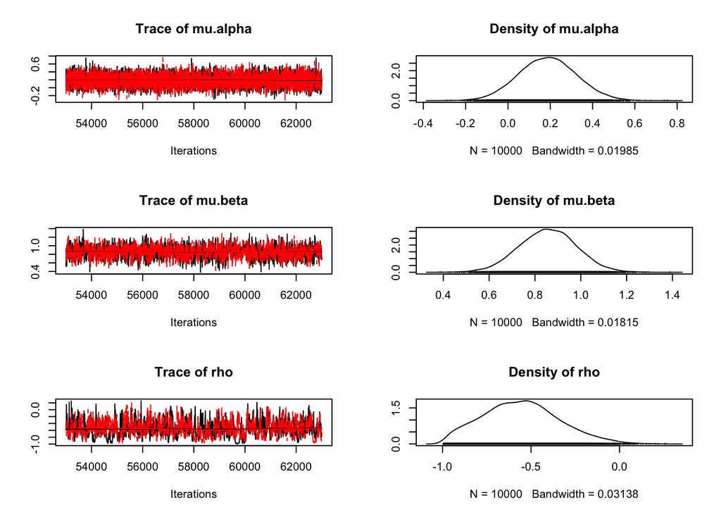

```r
update(jm.hier4, n.iter = n.update)
#You should run diagnostics on zc.hier coda object for intecepts and slopes but I eliminated them here to make output more compact
zc.hier4 = coda.samples(jm.hier4, variable.names = c('mu.alpha', "mu.beta", "rho"), n.iter=n.iter)
zj.hier4 = jags.samples(jm.hier4, variable.names = c("alpha", "beta", 'mu.alpha', "mu.beta", "rho"), n.iter=n.iter)
plot(zc.hier4)
```

```r
gelman.diag(zc.hier4)
```

```
## Potential scale reduction factors:
##
##          Point est. Upper C.I.
## mu.alpha          1          1
## mu.beta           1          1
## rho               1          1
##
## Multivariate psrf
##
## 1
```

```r
summary(zc.hier4)
```

```
##
## Iterations = 53001:63000
## Thinning interval = 1
## Number of chains = 2
## Sample size per chain = 10000
##
## 1. Empirical mean and standard deviation for each variable,
##    plus standard error of the mean:
##
##             Mean     SD  Naive SE Time-series SE
## mu.alpha  0.1873 0.1357 0.0009598       0.001937
## mu.beta   0.8559 0.1241 0.0008776       0.003243
## rho      -0.5551 0.2145 0.0015169       0.010313
##
## 2. Quantiles for each variable:
##
##              2.5%      25%     50%     75%   97.5%
## mu.alpha -0.07544  0.09479  0.1873  0.2786  0.4558
## mu.beta   0.61207  0.77192  0.8569  0.9396  1.0983
## rho      -0.93612 -0.71000 -0.5610 -0.4152 -0.1063
```

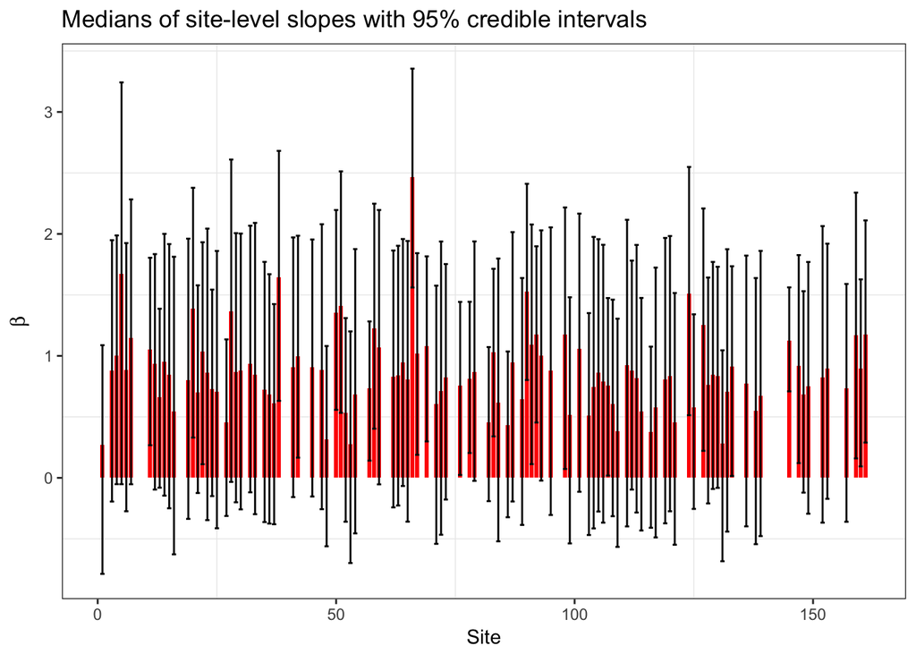

```r
#Make a vector to link sequential index (in ouput) to the group number.  Would work the same way if groups were character variables like names. t() is transpose. See group_from_index() function at top of file
slopes = t(summary(zj.hier4$beta, quantile, c(.025,.5,.975))$stat) #transpose is t() is important to make next function work
group.data=as.data.frame(group_from_index(group=y$group,group.index=y$group.index,output=slopes))
names(group.data)[3:5]=c("lower", "median", "upper")
library(ggplot2)
ggplot( group.data, aes(x = group, y = median)) +    geom_bar(position = position_dodge(), stat="identity", fill="red")  +   geom_errorbar(aes(ymin=lower, ymax=upper)) +   ggtitle("Medians of site-level slopes with 95% credible intervals") + # plot title
  labs(x="Site", y=expression(beta)) +
  theme_bw() + # remove grey background (because Tufte said so)
  theme(panel.grid.major = element_blank()) # remove x and y major grid lines (because Tufte said so)
```

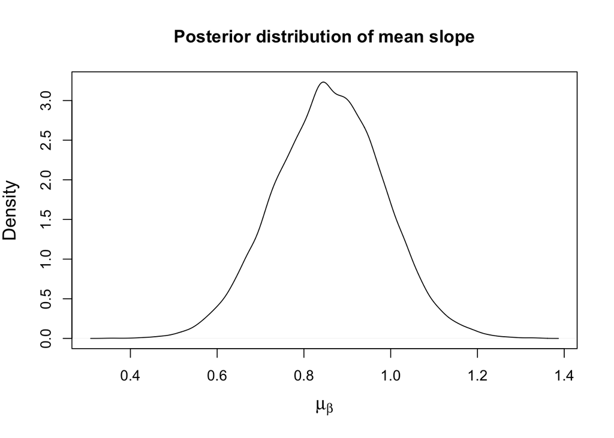

```r
plot(density(zj.hier4$mu.beta), xlab = expression(mu[beta]), main="Posterior distribution of mean slope", cex.lab=1.25)
```

#### VIII. Advanced problem 2: Model checking

### Motivation

This problem should be completed after the lecture and lab on model checking.

All statistical inference is based on some type of statistical model. A truly fundamental requirement for reliable inference is that the statistical model is capable of giving rise to the data. If this requirement is not met, you have *no* basis for inference. Statistical theory will not back you up. You are flying blind, proceeding bravely, perhaps foolishly, on your own. These truths motivate the need for model checking. Models that fail checks should be discarded at the outset. (This is *not* model selection. More about that later.)

The Bayesian approach provides a method, simple to implement, that allows you to check if your model is capable of producing the data. It is called a *posterior predictive check*. The details of the math are given Hobbs and Hooten 8.1 and were covered in lecture. Here is a brief description of how to code it. The algorithm goes like this:

1. Simulate a new data set at each iteration of the MCMC. This sounds formidable, but it is really no more than drawing a random variable from the likelihood. So, for example if your likelihood is

```r
y[i] ~ dnorm(log_mu[i], tau)
```

you can simulate a new data set by embedding

```r
y.sim[i] ~ dnorm(log_mu[i], tau)
```

in the same `for` loop.

2. Calculate a test statistic based on the real and the simulated data. The test statistic could be a mean, standard deviation, coefficient of variation, discrepancy, minimum, maximum – really any function that helps you compare the simulated and real data. I think it is wise to always include a test statistic that in someway reflects the variance because it is harder for the model to get the variance
3. We are interested in calculating a Bayesian p value, the probability that the test statistic computed from the simulated data is more extreme than the test statistic computed from the real data. There is evidence of lack of fit – the model cannot give rise to the data – if the Bayesian p value is large or small. We want values between, say, .10 and .90, ideally close to .5. To obtain this the Bayesian p we use the JAGS `step(x)` function that returns 0 if x is less 0 and and 1 otherwise. So, presume our test statistic for was the standard deviation. Consider the following pseudo-code:

```r
for(i in 1:length(y)){
  mu[i] <- prediction from model
  y[i] ~ dnorm(mu[i], tau)
  y.sim[i] ~ dnorm(mu[i], tau)
}
sd.data<-sd(y[])
sd.sim <-sd(y.sim[])
p.sd <- step(sd.sim - sd.data)
```

That is all there is to it. You then include `p.sd` in your jags or coda object.

### Problem

Return to the pooled model you developed in the first problem of the multi-level modeling exercise. Do posterior predictive checks using the mean, standard deviation, minimum, and discrepancy as test statistics. The discrepancy statistic is is $\sum_{i=1}^{n}(y_i-\mu_i)^2$ where $\mu_i$ is the $i^th$ prediction of your model. Overlay the posterior distribution of the simulated data on the histogram of the read data (density on y axis, not frequency). What do you conclude? Is there any indication of lack of fit? Enough to discard the model?

```r
#preliminaries
library(rjags)
library(reshape)
library(ggplot2)
set.seed(5)
#setwd("/Users/Tom/Documents/Ecological Modeling Course/_A_Master_Lab_Exercises/Multi-level models NO2/")
y.n.sites = length(unique(y$group))

#data for all models except last one
data = list(
  y.emission = log(y$emission),
  y.n.input = log(y$n.input) - mean(log(y$n.input)) #center the data to speed convergence and aid in interpretation. Can recover 0 intercept if needed.

)



inits = list(
  list(
    alpha = 0,
    beta = .5,
    sigma = 50
  ),
  list(
    alpha = 1,
    beta = 1.5,
    sigma = 10
  )
)
```